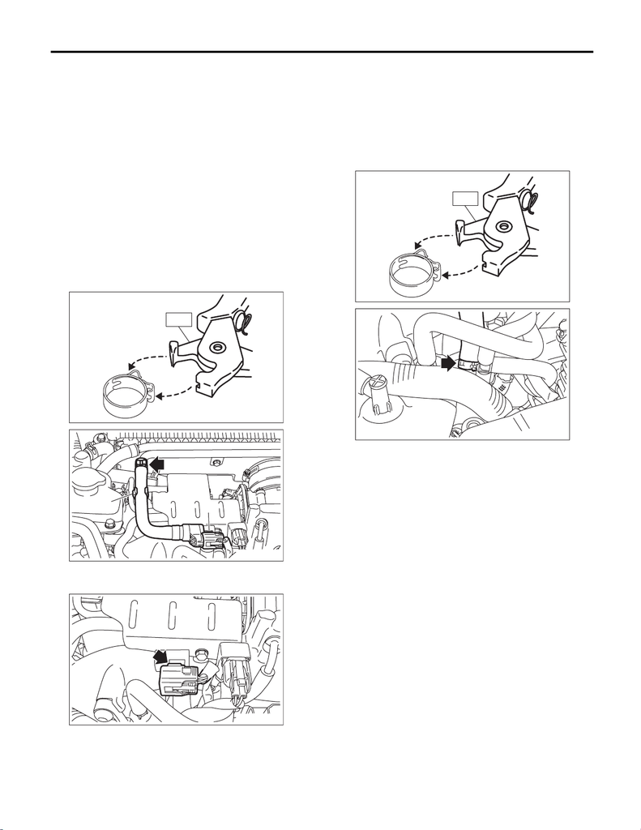

EC(STI)-49

PCV Hose Assembly

EMISSION CONTROL (AUX. EMISSION CONTROL DEVICES)

10.PCV Hose Assembly

A: REMOVAL

CAUTION:

Do not remove unless the hose and the diag-

nostics connector are broken.

1) Disconnect the connector (A) from the PCV hose

assembly A.

2) Remove the PCV hose assembly A from the clip

(B), and remove the PCV hose assembly A from

the PCV pipe.

NOTE:

Pinch the clamp of the PCV hose assembly A by fit-

ting the cut out in the ST with the protrusion on the

clamp as shown in the figure, and unlock the

clamp.

ST 18353AA000 CLAMP PLIERS

3) Remove the connector from the PCV hose as-

sembly B.

4) Remove the PCV hose assembly B from the in-

take duct.

NOTE:

Pinch the clamp of the PCV hose assembly B by fit-

ting the cut out in the ST with the protrusion on the

clamp as shown in the figure, and unlock the

clamp.

ST 18353AA000 CLAMP PLIERS

5) Remove the intake manifold. <Ref. to FU(STI)-

17, REMOVAL, Intake Manifold.>

6) Remove the turbocharger. <Ref. to IN(STI)-16,

REMOVAL, Turbocharger.>

ME-04374

ST

EC-03448

(B)

(A)

EC-03008

ME-04374

ST

EC-03449

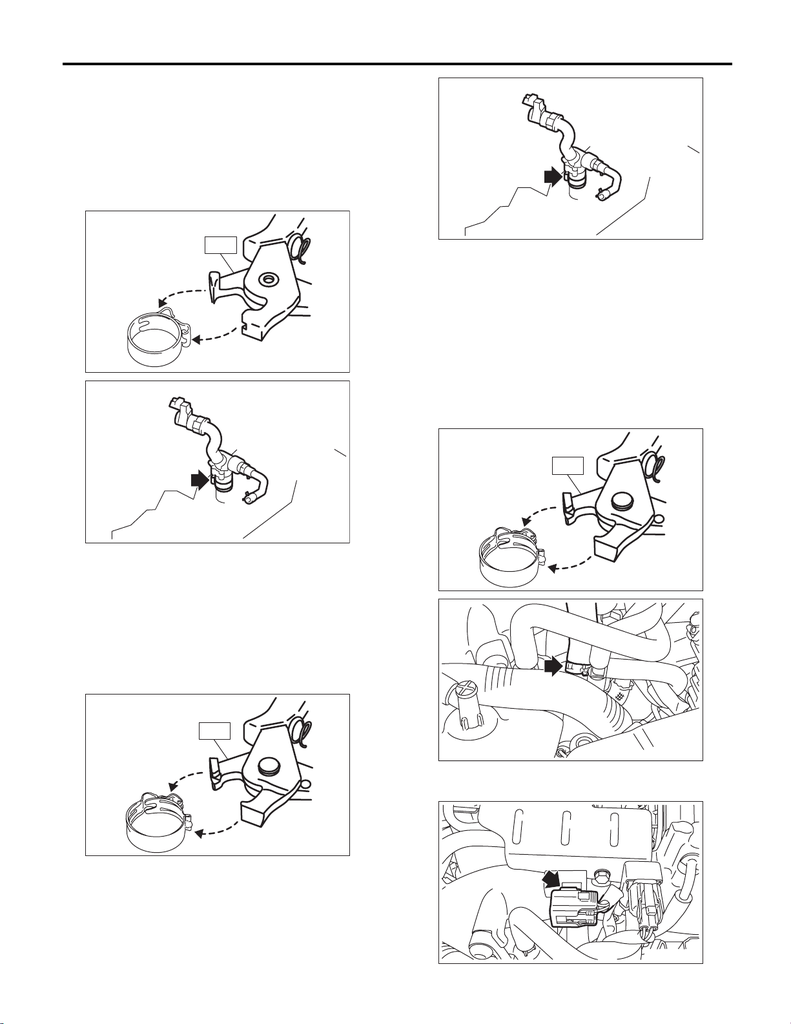

EC(STI)-50

PCV Hose Assembly

EMISSION CONTROL (AUX. EMISSION CONTROL DEVICES)

7) Remove the PCV hose assembly C from the cyl-

inder block RH.

NOTE:

Pinch the clamp of the PCV hose assembly C by fit-

ting the cut out in the ST with the protrusion on the

clamp as shown in the figure, and unlock the

clamp.

ST 18353AA000 CLAMP PLIERS

B: INSTALLATION

1) Install the PCV hose assembly C onto the cylin-

der block RH.

NOTE:

Use a new clamp for the PCV hose assembly C, fit

the cut out in the ST with the protrusion on the

clamp as shown in the figure, and lock the clamp.

ST 18353AA000 CLAMP PLIERS

2) Install the turbocharger. <Ref. to IN(STI)-17, IN-

STALLATION, Turbocharger.>

3) Install the intake manifold. <Ref. to FU(STI)-21,

INSTALLATION, Intake Manifold.>

4) Install the PCV hose assembly B onto the intake

duct.

NOTE:

Use a new clamp for the PCV hose assembly B, fit

the cut out in the ST with the protrusion on the

clamp as shown in the figure, and lock the clamp.

ST 18353AA000 CLAMP PLIERS

5) Connect the connector to the PCV hose assem-

bly B.

ME-04374

ST

EC-03011

ME-08033

ST

EC-03011

ME-08033

ST

EC-03449

EC-03008

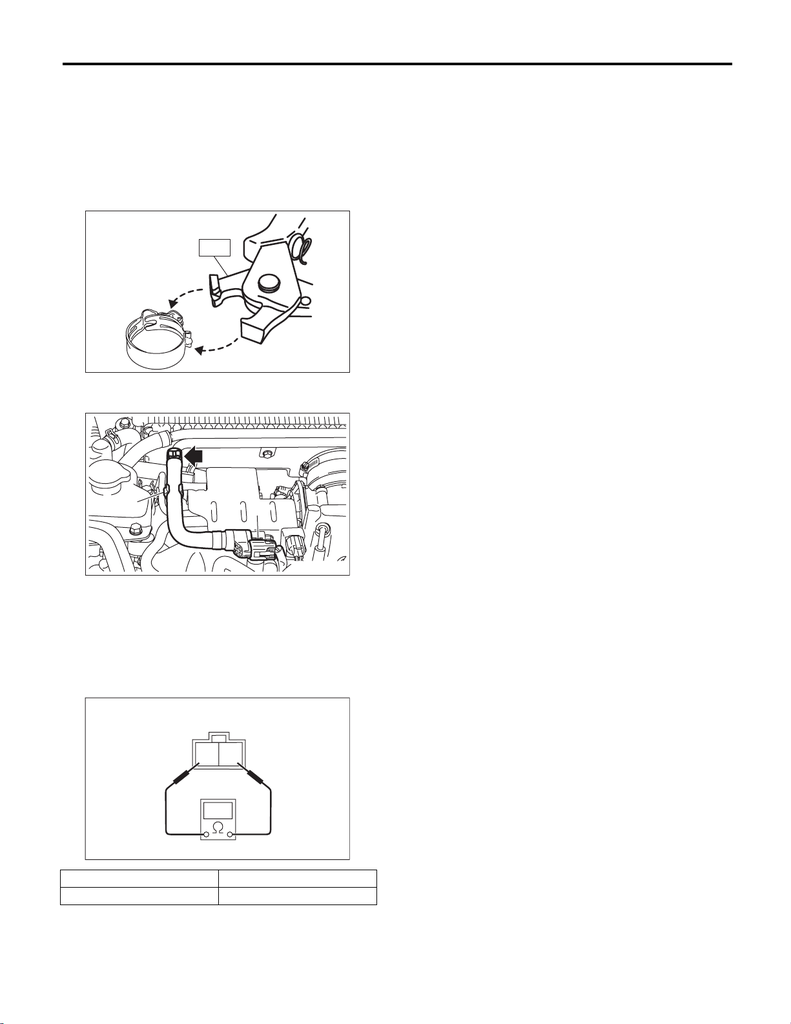

EC(STI)-51

PCV Hose Assembly

EMISSION CONTROL (AUX. EMISSION CONTROL DEVICES)

6) Install the PCV hose assembly A to the PCV

pipe, and install the PCV hose assembly A to the

clip (B).

NOTE:

Use a new clamp for the PCV hose assembly A, fit

the cut out in the ST with the protrusion on the

clamp as shown in the figure, and lock the clamp.

ST 18353AA000 CLAMP PLIERS

7) Connect the connector (A) to the PCV hose as-

sembly A.

C: INSPECTION

1. DIAGNOSIS CONNECTOR

1) Check that the diagnosis connector has no de-

formation, cracks and any other damage.

2) Check the resistance between the diagnosis

connector terminals.

2. OTHER INSPECTIONS

1) Check that the PCV connector has no deforma-

tion, cracks or other damages.

2) Check that the hose has no cracks, damage or

loose part.

Terminal No. Standard

1 and 2 Less than 1 Ω

ME-08033

ST

EC-03448

(B)

(A)

2

1

EC-02428